# Predictive Modeling in R with Applications in Trading

May 30, 2018

## Framework

Key components of the research and strategy development process.

- Constraints and Objectives
- Testable Hypothesis
- Model Building and Evaluation
- Backtesting

See Peterson (2015) for complete discussion of strategy development.

## Constraints

- Capital Requirements:
  - How much capital to I need to execute the strategy?
- Market Access:
  - What accounts, exchanges, and banking/clearing relationships do I need?
  - What instruments can I trade? Can I short?
- Infrastructure:
  - Server(s), trading platform, feed handler, order routing, risk checks.
- Fees:
  - What does it cost me to trade?

## Objectives

- Make money trading cryptocurrencies
- Define the type of risk and return profiles you are targeting
  - Risk adjusted return measures
  - Drawdown and other tail risk measures
  - Market observable measures
    - $/contract, % daily volume, $/day

## Hypothesis

- Define a **testable** hypothesis that makes a prediction about market behavior with a defined outcome and conditions to reject the hypothesis.
- Bad: Hypothesize that trades contain information.
- Better: Hypothesize that the direction of the aggressor trade is predictive of the next price change.
- Better: Hypothesize that the net trade flow over a specified period is predictive of the price change direction over the next period.

Reject the hypothesis if the predictive accuracy is no better than random. If the hypothesis is rejected, then start over. **DO NOT** just change your hypothesis.

## Data Setup

- GDAX LTCUSD tick data from April 11, 2018 to April 26, 2018
- Bar Aggregation
  - Arbitrary time bars (e.g. 1 sec, 5 min, 10, min, 1 hour)
  - Tick bars
  - Event time, see Gençay et al. (2001).
  - Volume and dollar bars, see Easley, Lopez de Prado, and O’Hara (2012) and Lopez de Prado (2018).
  - Information driven bars, see Lopez de Prado (2018).
- In Sample vs. Out of Sample (i.e. training vs testing)

## Data Visualization: L1 Tick Data

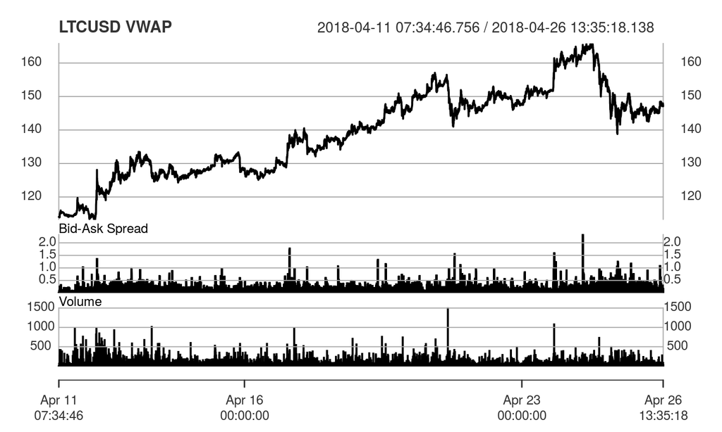

## Data Visualization: Subset

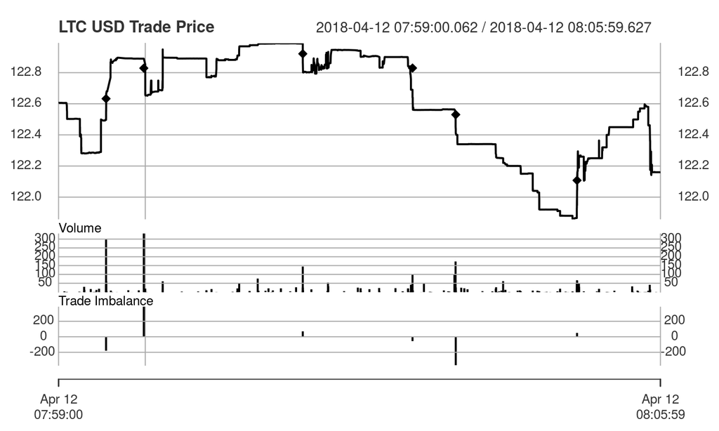

## Data Visualization: Subset

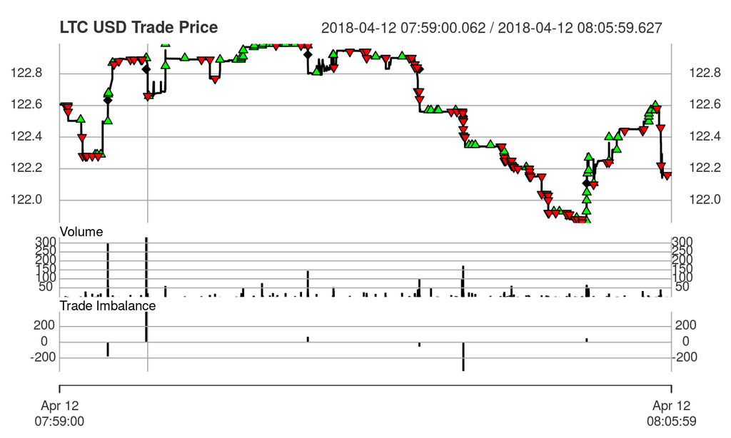

## Data Visualization: Volume Bar Data

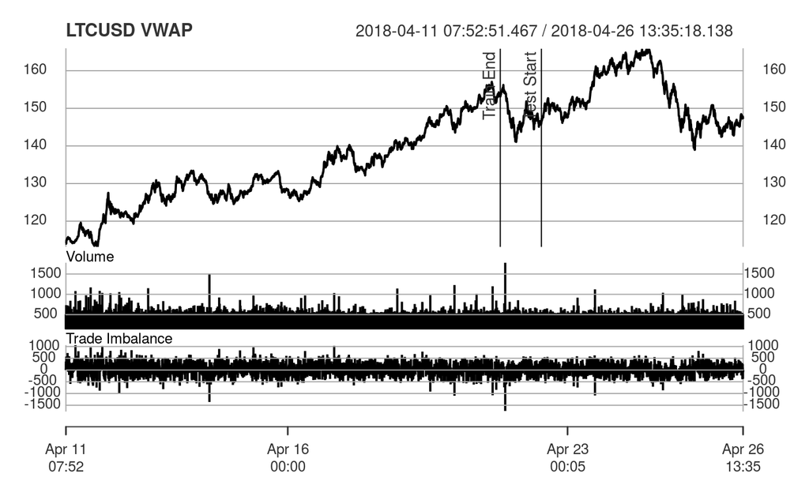

## Model Setup and Hypothesis Test

```r
# Fit a simple model using logistic regression
# glm treats the second factor as the event of interest
data.train <- as.data.frame(na.omit(x.train[,c("Trade.Imbalance",
                                               "Next.Change.Sign")]))
data.train$Next.Change.Sign <- factor(data.train$Next.Change.Sign,
                                      levels = c("0", "1"))
m1 <- glm(Next.Change.Sign ~ Trade.Imbalance,
          data = data.train, family = binomial(link = "logit"))
```

```r
summary(m1)
```

```
##
## Call:
## glm(formula = Next.Change.Sign ~ Trade.Imbalance, family = binomial(link = "logit"),
##     data = data.train)
##
## Deviance Residuals:
##     Min       1Q   Median       3Q      Max
## -2.6705  -1.0234   0.5744   0.9736   2.7632
##
## Coefficients:
##                   Estimate Std. Error z value Pr(>|z|)
## (Intercept)     -0.0712101  0.0368979   -1.93   0.0536 .
## Trade.Imbalance  0.0034004  0.0001472   23.11   <2e-16 ***
## ---
## Signif. codes:  0 '***' 0.001 '**' 0.01 '*' 0.05 '.' 0.1 ' ' 1
##
## (Dispersion parameter for binomial family taken to be 1)
##
##     Null deviance: 5103.9  on 3687  degrees of freedom
## Residual deviance: 4427.6  on 3686  degrees of freedom
## AIC: 4431.6
##
## Number of Fisher Scoring iterations: 3
```

## In Sample Confusion Matrix

```
## Confusion Matrix and Statistics
##
##           Reference
## Prediction    0    1
##          0 1122  529
##          1  632 1405
##
##                Accuracy : 0.6852
##                  95% CI : (0.6699, 0.7002)
##     No Information Rate : 0.5244
##     P-Value [Acc > NIR] : < 2.2e-16
##
##                   Kappa : 0.3672
##  Mcnemar's Test P-Value : 0.002758
##
##             Sensitivity : 0.7265
##             Specificity : 0.6397
##          Pos Pred Value : 0.6897
##          Neg Pred Value : 0.6796
##              Prevalence : 0.5244
##          Detection Rate : 0.3810
##    Detection Prevalence : 0.5523
##       Balanced Accuracy : 0.6831
##
##        'Positive' Class : 1
##
```

## Out of Sample Confusion Matrix

```
## Confusion Matrix and Statistics
##
##           Reference
## Prediction   0   1
##          0 559 264
##          1 275 614
##
##                Accuracy : 0.6852
##                  95% CI : (0.6626, 0.7071)
##     No Information Rate : 0.5129
##     P-Value [Acc > NIR] : <2e-16
##
##                   Kappa : 0.3697
##  Mcnemar's Test P-Value : 0.6667
##
##             Sensitivity : 0.6993
##             Specificity : 0.6703
##          Pos Pred Value : 0.6907
##          Neg Pred Value : 0.6792
##              Prevalence : 0.5129
##          Detection Rate : 0.3586
##    Detection Prevalence : 0.5193
##       Balanced Accuracy : 0.6848
##
##        'Positive' Class : 1
##
```

## Standard K-Fold Cross Validation

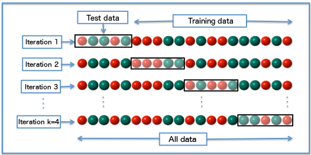

source: https://upload.wikimedia.org/wikipedia/commons/1/1c/K-fold_cross_validation_EN.jpg

WARN: use for time series at your own peril!

## Time Series Cross Validation

Time series cross validation (i.e. walk forward), see Hyndman and Athanasopoulos (2018).

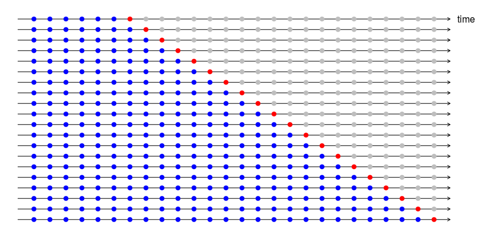

source: https://robjhyndman.com/hyndsight/tscv/

## Purged K-Fold Cross Validation

Purged k-fold cross validation with embargo periods, see Lopez de Prado (2018).

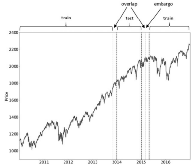

source: Lopez de Prado (2018)

## Cross Validation for Higher Frequency Time Series

Apply time series cross validation/walk forward analysis at a specified frequency

```r
ep.d <- endpoints(x.train, on = "days")
index.cv <- list()
index.cv$index.in <- index.cv$index.out <- list()
j <- 1
for(i in 6:length(ep.d)-1){
  index.cv$index.in[[j]] <- 1:ep.d[i]
  index.cv$index.out[[j]] <- (ep.d[i] + 1):ep.d[i+1]
  j <- j + 1
}
```

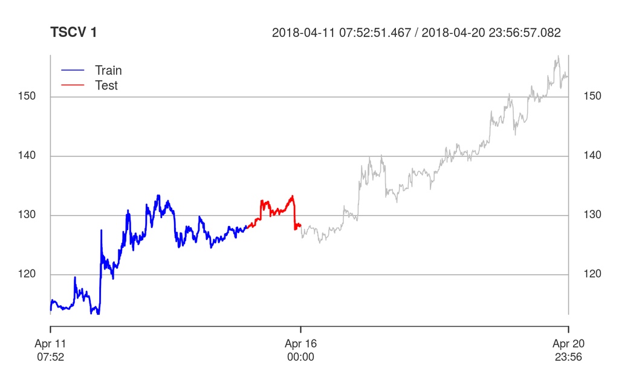

## Cross Validation for Higher Frequency Time Series

```r
# Use caret::trainControl with our index.cv object
tc <- trainControl(method = "timeslice", index = index.cv$index.in,
                   indexOut = index.cv$index.out)
mc <- train(Next.Change.Sign ~ Trade.Imbalance, data = data.train,
            method = "glm", family = binomial(link = "logit"),
            trControl = tc)
mc
```

```
## Generalized Linear Model
##
## 3688 samples
##    1 predictors
##    2 classes: '0', '1'
##
## No pre-processing
## Resampling: Rolling Forecasting Origin Resampling (1 held-out with a fixed window)
## Summary of sample sizes: 1555, 1883, 2149, 2587, 2913, 3300, ...
## Resampling results:
##
##   Accuracy   Kappa
##   0.6829004  0.3624215
```

## Model Evaluation

Fit the following model. Consider multiple classification algorithms, both linear and non-linear

```
Next.Change.Sign ~ Trade.Imbalance + Trade.Imbalance.Diff
```

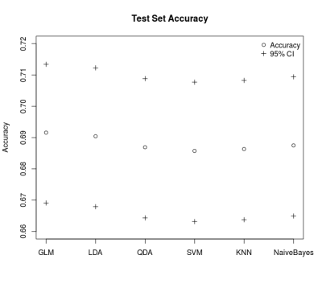

* model tuning done using time series cross validation index defined earlier

## Model Robustness

Does the model work on other cryptocurrencies, asset classes, and/or frequencies?

Two factor logistic regression model on more coins. Training set of 2018-04-11 through 2018-04-20 and test set of 2018-04-22 through 2018-04-26.

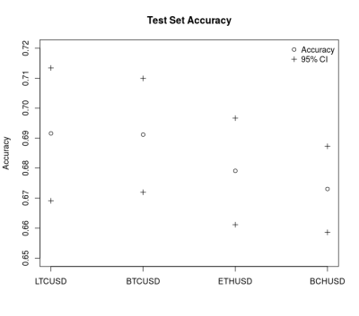

## Strategy Framework with Models

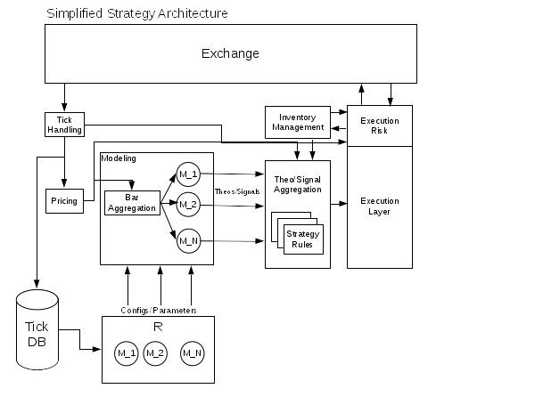

## Future Work

- Custom loss function.
- More data.
- Evaluate more models, e.g. classification trees and rule-based models, as well as boosting and bagging techniques.
- More features, e.g. regime changes, structural breaks, and microstructure. Feature importance analysis.

## Conclusion

- Think about your features.
- Do not blindly apply standard predictive modeling/machine learning techniques such as cross validation and bootstrapping.
- Be cognizant of the dangers of overfitting, data leakage, and biases.
- Follow a framework or process that is designed to avoid these common mistakes.

Presentation source, analysis scripts, and data:

https://github.com/rossb34/PredictiveModeling_20180530

https://rossb34.github.io/PredictiveModeling_20180530

## References

Easley, David, Marcos Lopez de Prado, and Maureen O’Hara. 2012. “The Volume Clock: Insights into the High Frequency Paradigm.”

Gençay, Ramazan, Michel Dacorogna, Ulrich A Muller, Olivier Pictet, and Richard Olsen. 2001. *An Introduction to High-Frequency Finance*. Elsevier.

Hyndman, Rob J, and George Athanasopoulos. 2018. *Forecasting: Principles and Practice*. OTexts.

Lopez de Prado, Marcos. 2018. *Advances in Financial Machine Learning*. John Wiley & Sons.

Peterson, Brian G. 2015. “Developing & Backtesting Systematic Trading Strategies.” DV Trading. http://goo.gl/na4u5d.